# Визуализация данных

## Визуализация данных с использованием простейшей статистической обработки

## Боксплоты

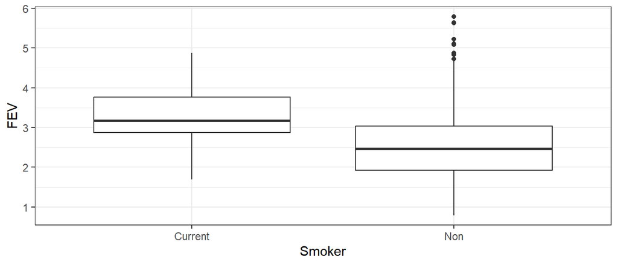

```r
ggplot(fev, aes(x = Smoker, y = FEV)) +
  geom_boxplot()
```

Становится видна некоторая тенденция

## Боксплоты

Отразим данные по полу

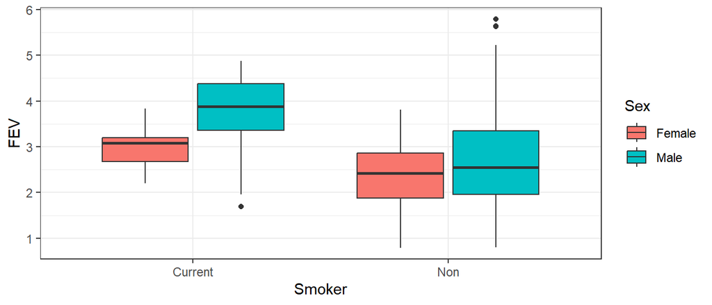

```r
ggplot(fev, aes(x = Smoker, y = FEV)) +
  geom_boxplot(aes(fill = Sex))
```

Тенденция видна лучше

## Задача: отразить срдний объем легких у разных возрастов для некурящих

Для этого нам надо сделать следующие действия

1. Отфильтровать из датафрейма тех людей, которые не курят
2. Сгруппировать людей по возрасту
3. Для каждой группы посчитать среднее значение (и другие статистические показатели)
4. Нарисовать график

## Знакомимся с пакетом `dplyr`

```r
library(dplyr)

fev_summary <-
fev %>%
  filter(Smoker == "Non") %>%
  group_by(Age) %>%
  summarize(Mean_FEV = mean(FEV))
```

Оператор %>% обеспечивает конвейерную передачу объектов

Его можно вставить сочетанием клавиш Ctrl + Shift + M

## Строим график

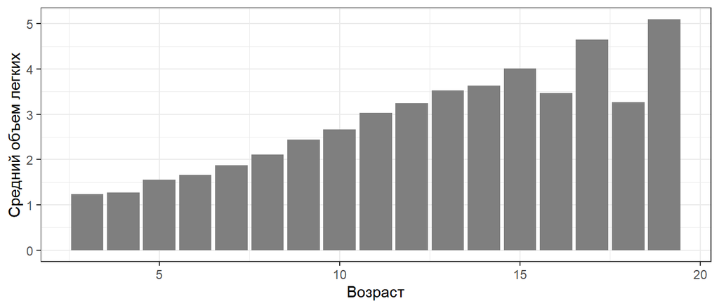

```r
ggplot(fev_summary, aes(x = Age, y = Mean_FEV)) +
  geom_col(fill = "gray50") +
  labs(x = "Возраст", y = "Средний объем легких")
```

## Строим график

Аналогичный график но в одном конвейере

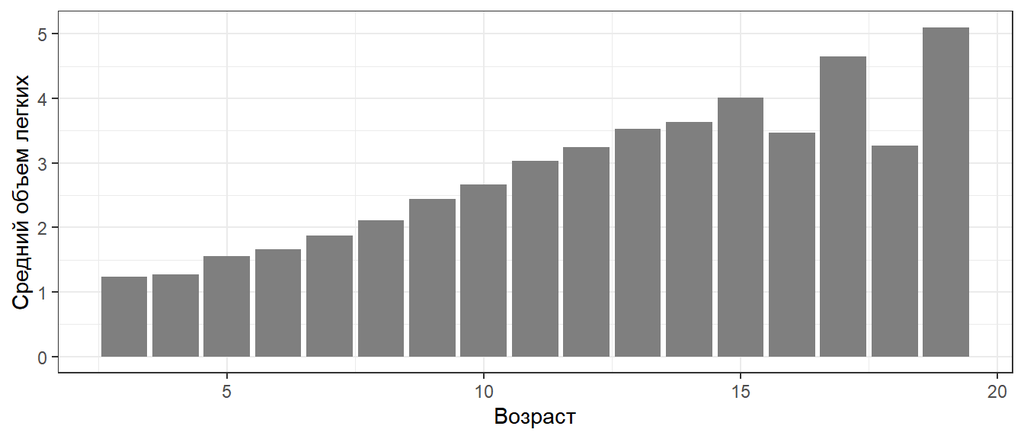

```r
fev %>%
  filter(Smoker == "Non") %>%
  group_by(Age) %>%
  summarize(Mean_FEV = mean(FEV)) %>%
    ggplot(aes(x = Age, y = Mean_FEV)) +
      geom_col(fill = "gray50") +
      labs(x = "Возраст", y = "Средний объем легких")
```

## Добавляем данные по полу

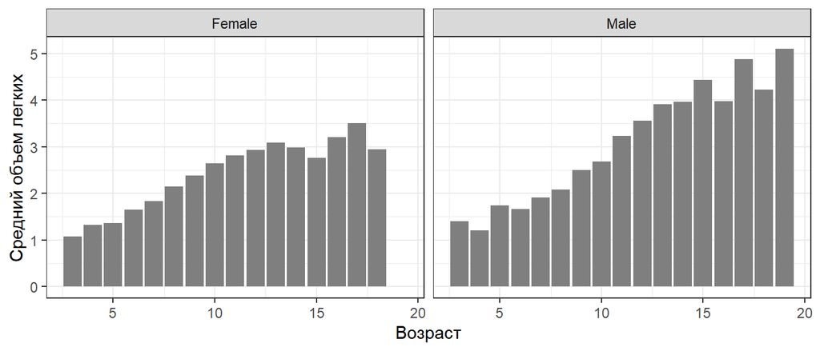

```r
fev %>%
  filter(Smoker == "Non") %>%
  group_by(Age, Sex) %>%  # Добавили еще одну группирующую переменную
  summarize(Mean_FEV = mean(FEV)) %>%
    ggplot(aes(x = Age, y = Mean_FEV)) +
      geom_col(fill = "gray50") +
      labs(x = "Возраст", y = "Средний объем легких") +
      facet_wrap(~Sex)
```

## Добавляем информацию о варьировании объема легких

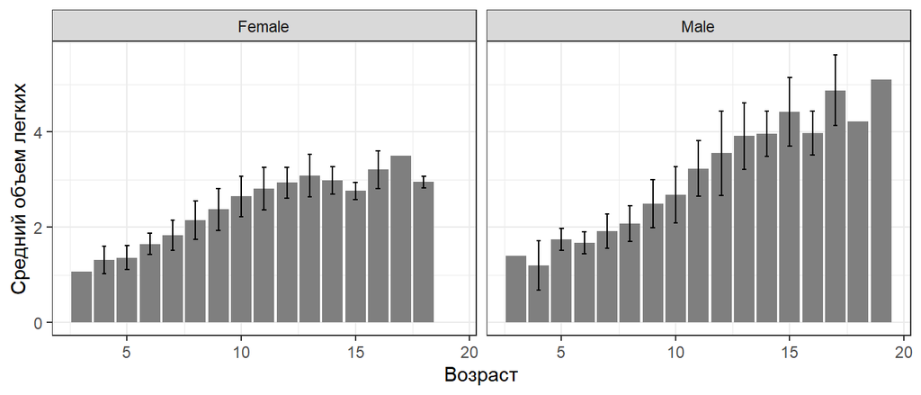

```r
fev %>%
  filter(Smoker == "Non") %>%
  group_by(Age, Sex) %>%
  summarize(Mean_FEV = mean(FEV), SD = sd(FEV)) %>%
    ggplot(aes(x = Age, y = Mean_FEV)) +
      geom_col(fill = "gray50") +
      geom_errorbar(aes(ymin = Mean_FEV - SD, ymax = Mean_FEV + SD), width = 0.2) +
      labs(x = "Возраст", y = "Средний объем легких") +
      facet_wrap(~Sex)
```

## Учитываем информацию о курении

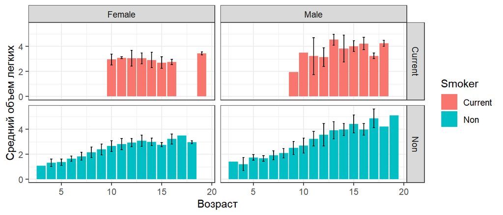

```r
fev %>%
  group_by(Age, Sex, Smoker) %>%
  summarize(Mean_FEV = mean(FEV), SD = sd(FEV)) %>%
    ggplot(aes(x = Age, y = Mean_FEV)) +
      geom_col(aes(fill = Smoker)) +
      geom_errorbar(aes(ymin = Mean_FEV - SD, ymax = Mean_FEV + SD), width = 0.2) +
      labs(x = "Возраст", y = "Средний объем легких") +
      facet_grid(Smoker~Sex)
```

## Задание:

### Постройте столбчатые диаграммы, отражающие средний рост у представителей разного пола

## Решение

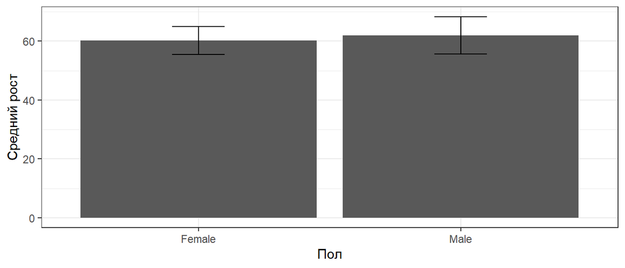

```r
fev %>%
  group_by(Sex) %>%
  summarize(Mean_Height  = mean(Height), SD = sd(Height)) %>%
    ggplot(aes(x = Sex, y = Mean_Height)) +
      geom_col() +
      geom_errorbar(aes(ymin = Mean_Height - SD, ymax = Mean_Height + SD), width = 0.2) +
      labs(x = "Пол", y = "Средний рост")
```

## С помощью функций ggplot можно сразу вписать простые линейные модели и увидеть характер связей

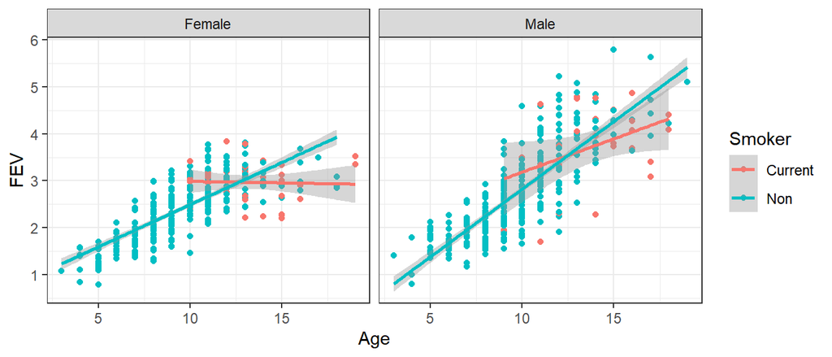

```r
ggplot(fev, aes(x = Age, y = FEV, color = Smoker)) +
  geom_point() +
  geom_smooth(method = "lm") +
  facet_wrap( ~ Sex)
```

## Take home messages

- Для анализа лучше подходит длинный формат
- Данные должны быть оформлены в соответствии с определнными правилами
- Пакет ggplot2 позволяет построить практически любой график

## Что почитать

[Cookbook for R](http://www.cookbook-r.com/Graphs/)